# Trial Specifications Document

North Pacific Swordfish MSE

# 1 Introduction

This document describes the technical details of the management strategy evaluation (MSE) framework being developed for the North Pacific Swordfish (NPSWO) fishery.

This is a living document and will be continually updated as the project progresses.

Currently the model uses NPSWO data through 2021. Life-history parameters and other technical specifications of the model (documented below) have not been reviewed by the ISC or other interested stakeholders, and may be revised and updated once the initial framework has been reviewed.

# 2 Data

The operating models have been conditioned using the same data used in the most recent stock assessment, conducted in 2023 with data up to 2021 (ISC 2023).

## 2.1 Catch

The NPSWO catches have been organized into 19 fleets (Table 2.1; Figure 2.1).

Table 2.1: The nineteen fleets used for the NPSWO catch data.

[output not shown]

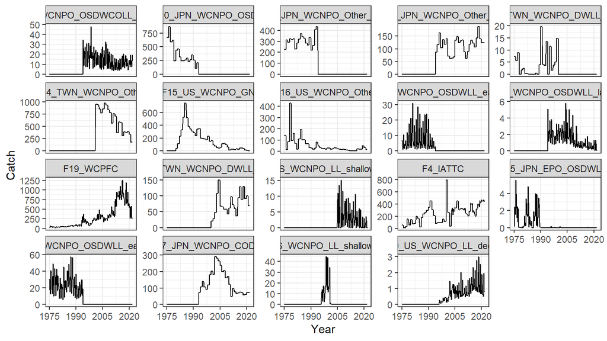

Figure 2.1: Time series plot of the NPSWO catch data by fleet.

## 2.2 Indices

Eight indices of abundance were considered in the 2023 NPSWO assessment; indices 5 & 8 were ultimately excluded from the base model (Table 2.2; Figure 2.2).

Table 2.2: The eight indices of abundance; indices 5 & 8 were ultimately excluded from the base model.

| Index | Fleet.Name | Time.Period |
| --- | --- | --- |
| 1 | JPN_WCNPO_OSDWLL_Early_Area2 | 1975 – 1993 |
| 2 | JPN_WCNPO_OSDWLL_Late_Area2 | 1994 – 2021 |
| 3 | JPN_WCNPO_OSDWLL_Early_Area1 | 1975 – 1993 |
| 4 | JPN_WCNPO_OSDWCOLL_Late_Area1 | 1994 – 2021 |
| 5 | TWN_WCNPO_DWLL_Late | 2000 – 2021 |
| 6 | US_WCNPO_LL_Deep | 1996 – 2021 |
| 7 | US_WCNPO_LL_Shallow_Early | 1996 – 2001 |
| 8 | US_WCNPO_LL_Shallow_Late | 2004 – 2021 |

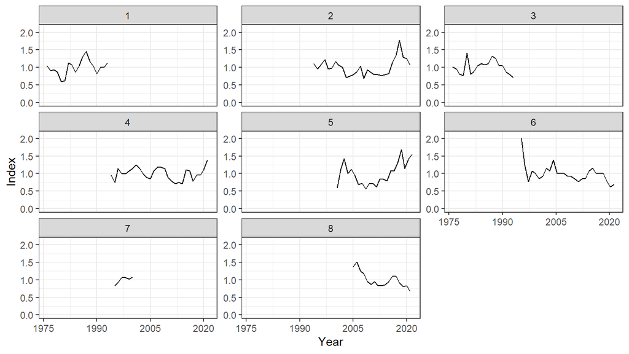

Figure 2.2: Time series plot of the NPSWO index data by fleet; indices 5 & 8 were ultimately excluded from the base model.

# 3 Base Life-History Parameters

Table 3.1 shows the base case values of the life history parameters.

Table 3.1: Life history parameters for the Base Case Operating Model

| Parameter | Description | Value.Female | Value.Male | Reference |
| --- | --- | --- | --- | --- |
| $M$ | Natural mortality rate (age-specific) | 0.42(0), 0.37(1), 0.32(2), 0.27(3), 0.22(4+) | 0.4(0), 0.38(1), 0.37(2), 0.37(3), 0.37(4), 0.37(5), 0.36(6+) | Kapur et al. (2017) |
| $L @ Amin$ | Length at minimum age (0.5) | 80.1 | 83.2 | DeMartini et al. (2007) |
| $L @ Amax$ | Length at maximum age (15) | 226.3 | 206.4 | DeMartini et al. (2007) |
| $K$ | Growth coefficient | 0.246 | 0.271 | DeMartini et al. (2007) |
| $a$ | Length-weight relationship; average weight at L=1 | 1.30E-05 | 1.30E-05 | DeMartini et al. (2007) |
| $b$ | Length-weight relationship exponent | 3.07 | 3.07 | DeMartini et al. (2007) |
| $L_{50}$ | Length corresponding with 50% probability of maturity | 143.68 | – | Kapur et al. (2017) |
| $h$ | Steepness of Beverton-Holt SRR | 0.9 | 0.9 | Brodziak (2020) |
| $\sigma_R$ | Standard deviation of the log-normally distributed recruitment deviations | 0.42 | 0.42 | Assumed |

# 4 Uncertainties in Life-History Parameters

The NPSWO MSE currently considers two axes of uncertainty in the life-history parameters (see Base Life-History Parameters):

1. Natural mortality (*M*)
2. Steepness of the Beverton-Holt stock-recruit relationship (*h*), converted to a compensation ratio (*CR*) (see Stochastic Sampling)

Additional uncertainties that could be considered for the life-history parameters include (but are not limited to):

1. Uncertainty in the von Bertalanffy growth parameters
2. Variation in the maturity parameters
3. Variation in the recruitment deviations

The uncertainty in the continuous life-history parameters was handled using stochastic sampling of the life-history parameters from a multivariate distribution. While some MSE processes such as the NPALB MSE (ISC 2021) have used a discrete uncertainty grid to capture uncertainty in life-history parameters, the stochastic sampling approach is much more computationally efficient and has the advantage that it can account for both down-weighting of less likely life-history parameters and correlations between life-history parameters.

## 4.1 Stochastic Sampling

The *Stochastic Sampling* approach involved sampling 200 values of the life-history parameters from a multivariate distribution, and running the OM Conditioning model (see next section) for each simulation. A single OM was then generated, incorporating the output of the 200 fits to the data with the stochastic life-history parameters.

The methodology for sampling the life-history parameters was based on the methodology developed by Taylor (2024) for the Southern Atlantic Swordfish.

The life-history parameters were assumed to be log-normally distributed (Table 4.1), and were sampled from a multivariate distribution truncated at 1.96 standard deviations. The truncation was used to exclude extreme values from the tails of the distribution. In this process, *h* values are converted internally to a compensation ratio, *CR*, which can take values from 0 - Inf, in order to complete the log transformation with the assumed coefficient of variation. Returned *CR* values are then back-converted to *h*.

The covariance matrix for the multivariate distribution was generated by using the correlation between *M* and *h* reported by the FishLife package (Thorson et al. 2023) for *Xiphias gladius.*

The mean base *M* values were taken from the most recent assessment (ISC (2023)) for the plus age group for females and males (4+ and 6+ respectively). Stchastically sampled *M* values for each simulation were then converted into age-specifc *M* for each sex, maintaining the original ratio between ages from the assessment.

Table 4.1: The mean and standard deviation used to generate the stochastic life-history parameters. The mean *CR* is equivalent to *h* = 0.9.

| Parameter | Mean | SD |
| --- | --- | --- |
| $M female$ | 0.22 | 0.10 |
| $M male$ | 0.36 | 0.10 |
| $CR$ | 36.00 | 0.25 |

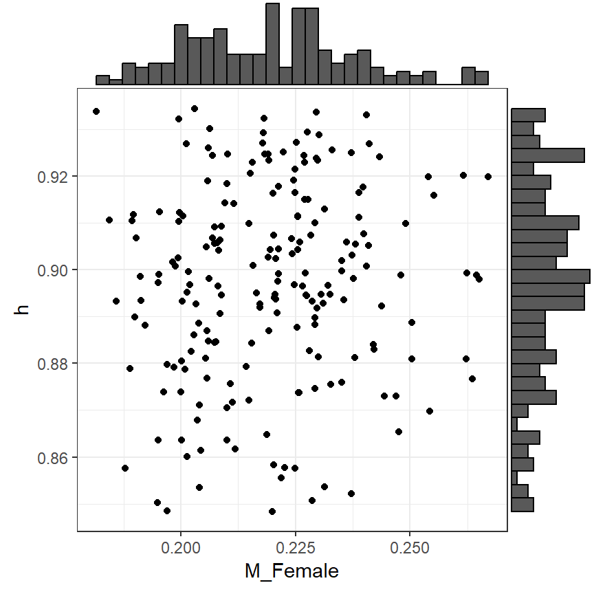

Figure 4.1: Scatterplot with marginal histograms of the samples of the stochastic life-history parameters for females.

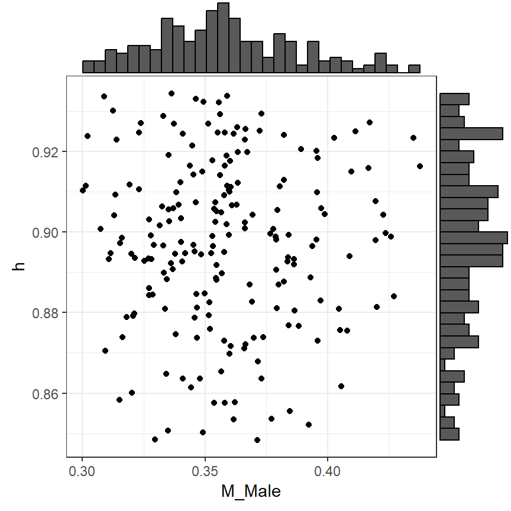

Figure 4.2: Scatterplot with marginal histograms of the samples of the stochastic life-history parameters for males.

# 5 OM Conditioning

The Operating Models were conditioned using the final base case [Stock Synthesis 3](https://nmfs-ost.github.io/ss3-website/) (SS3) model from the most recent NPSWO assessment (ISC (2023)). More details on the SS3 specifications and model diagnostics can be found [here](https://isc.fra.go.jp/pdf/ISC23/ISC23_ANNEX11-Stock_Assessment_Report_for_North_Pacific_Ocean_Swordfish_FINAL.pdf).

The SS3 model is one-area, two-sex, and structured for quarterly time steps. While technically a single-area model, stock boundaries for the Western and Central North Pacific Ocean (WCPO) and North Eastern Pacific Ocean (EPO) swordfish stocks are treated implicitly using fleets as areas.

The operating models had 200 simulations and a 25-year projection period.

## 5.1 Reference Operating Models

The Reference OMs spanned the primary uncertainties in the life-history parameters for this stock (see Section 4).

Reference OMs were generated using the *Stochastic Sampling* approach described above, which entailed running the SS3 model for each of the 200 samples of the life-history parameters, and then generating a single OM with 200 predictions of the historical fishery dynamics; i.e., a single OM that includes the stochastic variability in the life-history parameters.

## 5.2 Robustness Operating Models

A preliminary set of robustness OMs have been developed using the *Stochastic Sampling* approach described above that represent only the WCPO stock; fleets from the EPO are turned off in this set of models.

Other potential Robustness OMs (e.g., climate impacts) will be developed at a future date.

# References

Brodziak, J. 2020. “On the Probably Distribution of Stock-Recruitment Steepness for Western and Central North Pacific Swordfish.” *ISC/20/BILLWG-01/06*.

DeMartini, EE, JH Uchiyama, RL Humphreys Jr., JD Sampaga, and HA Williams. 2007. “Age and Growth of Swordfish (Xiphias Gladius) Caught by the Hawaii-Based Pelagic Longline Fishery.” *Fisheries Bulletin* 105: 356–67.

ISC. 2021. “Report of the North Pacific Albacore Tuna Management Strategy Evaluation.” https://isc.fra.go.jp/pdf/ISC21/ISC21_ANNEX11_Report_of_the_North_Pacific_ALBACORE_MSE.pdf.

———. 2023. “Stock Assessment Report for Swordfish (Xiphias Gladius) in the North Pacific Through 2021.” https://isc.fra.go.jp/pdf/ISC23/ISC23_ANNEX11-Stock_Assessment_Report_for_North_Pacific_Ocean_Swordfish_FINAL.pdf.

Kapur, M, J Brodziak, E Fletcher, and A Yau. 2017. “Summary of Life History and Stock Assessment Results for Pacific Blue Marlin, Western and Central North Pacific Striped Marlin, and North Pacific Swordfish.” *ISC/17/BILLWG-01/02*.

Taylor, Nathan G. 2024. “An Overview of the Southern Swordfish Closed-Loop Simulation Approach.” *Collect. Vol. Sci. Pap. ICCAT*, no. 81(7), SCRS/2024/016: 1-16.

Thorson, James T., Aurore A. Maureaud, Romain Frelat, Bastien Mérigot, Jennifer S. Bigman, Sarah T. Friedman, Maria Lourdes D. Palomares, Malin L. Pinsky, Samantha A. Price, and Peter Wainwright. 2023. “Identifying Direct and Indirect Associations Among Traits by Merging Phylogenetic Comparative Methods and Structural Equation Models.” *Methods in Ecology and Evolution* 14 (5): 1259–75. https://doi.org/10.1111/2041-210X.14076.